# 17.1: Simple linear regression

## Introduction

This is code for Section 17.1 of Kruschke using a normal noise distribution. Make sure that the two files “WtHtData30.csv” and “WtHtData300.csv” are in your project directory.

## Preliminaries

Load necessary packages:

```r
library(tidyverse)
library(rstan)
library(shinystan)
library(bayesplot)
```

Set Stan to save compiled code.

```r
rstan_options(auto_write = TRUE)
```

Set Stan to use parallel processing where possible.

```r
options(mc.cores = parallel::detectCores())
```

## Data

```r
WtHtData30 <- read_csv("WtHtData30.csv")
WtHtData30
```

| male | height | weight |
| --- | --- | --- |
| 0 | 64.0 | 136.4 |
| 0 | 62.3 | 215.1 |
| 1 | 67.9 | 173.6 |
| 0 | 64.2 | 117.3 |
| 0 | 64.8 | 123.3 |
| 0 | 57.5 | 96.5 |
| 0 | 65.6 | 178.3 |
| 1 | 70.2 | 191.1 |
| 0 | 63.9 | 158.0 |
| 1 | 71.1 | 193.9 |

[output cut: 20 more lines]

```r
WtHtData300 <- read_csv("WtHtData300.csv")
WtHtData300
```

| male | height | weight |
| --- | --- | --- |
| 0 | 64.0 | 136.4 |
| 0 | 62.3 | 215.1 |
| 1 | 67.9 | 173.6 |
| 0 | 64.2 | 117.3 |
| 0 | 64.8 | 123.3 |
| 0 | 57.5 | 96.5 |
| 0 | 65.6 | 178.3 |
| 1 | 70.2 | 191.1 |
| 0 | 63.9 | 158.0 |
| 1 | 71.1 | 193.9 |

[output cut: 290 more lines]

We’ll also be interested in comparing the results of using the raw data versus mean-centering the x variable. (Kruschke standardizes both variables using z-scores, but that makes the coefficients of the model harder to interpret.)

```r
x30_mc <- WtHtData30$height - mean(WtHtData30$height)
x300_mc <- WtHtData300$height - mean(WtHtData300$height)
```

We’re going to run three different examples, so we’ll make three lists.

```r
N30 <- NROW(WtHtData30)
x30 <- WtHtData30$height
y30 <- WtHtData30$weight
stan_data_30 <- list(N = N30, x = x30, y = y30)
```

```r
stan_data_30_mc <- list(N = N30, x = x30_mc, y = y30)
```

```r
N300 <- NROW(WtHtData300)
y300 <- WtHtData300$weight
stan_data_300_mc <- list(N = N300, x = x300_mc, y = y300)
```

## Stan code

We set normal priors on the $\beta_{0}$ (intercept) and $\beta_{1}$ parameters centered at reasonable values and spread over a wide range. The normal model for the likelihood is centered at `mu`, but `mu` is really a vector of values that represent the mean y value for each value of x, which is a point that lies on our regression line, hence the code in the `transformed parameters` block:

```
mu = beta0 + beta1 * x;
```

```stan
data {
    int<lower = 0> N;
    vector[N] x;
    vector<lower = 0>[N] y;
}
transformed data {
    real<lower = 0> M0;
    real<lower = 0> S0;
    real<lower = 0> M1;
    real<lower = 0> S1;
    real<lower = 0> L;
    real<lower = 0> H;

    M0 = 70;
    S0 = 70;
    M1 = 0;
    S1 = 3;
    L = 0;
    H = 1000;
}
parameters {
    real beta0;
    real beta1;
    real<lower = 0> sigma;
}
transformed parameters {
    vector<lower = 0>[N] mu;

    mu = beta0 + beta1 * x;
}
model {
    beta0 ~ normal(M0, S0);
    beta1 ~ normal(M1, S1);
    sigma ~ uniform(L, H);
    y ~ normal(mu, sigma);
}
generated quantities {
    real y_rep[N];

    for (n in 1:N) {
        y_rep[n] = normal_rng(mu[n], sigma);
    }
}
```

## Sampling from the model

```r
set.seed(11111)
fit_WtHt30 <- sampling(WtHt, data = stan_data_30, refresh = 0)
```

## Diagnosing the model

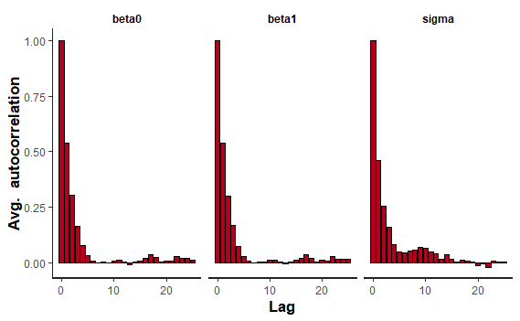

```r
plot(fit_WtHt30, plotfun = "ac", pars = c("beta0", "beta1", "sigma"))
```

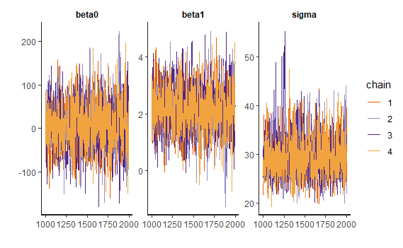

```r
plot(fit_WtHt30, plotfun = "trace",
     pars = c("beta0", "beta1", "sigma"))
```

## Summarizing the model

```r
print(fit_WtHt30, pars = c("beta0", "beta1", "sigma"))
```

```
Inference for Stan model: stan-d2c73141751.
4 chains, each with iter=2000; warmup=1000; thin=1;
post-warmup draws per chain=1000, total post-warmup draws=4000.

       mean se_mean    sd   2.5%    25%   50%   75%  97.5% n_eff
beta0  6.35    1.60 54.31 -98.62 -30.82  5.94 42.69 111.45  1158
beta1  2.21    0.02  0.81   0.62   1.68  2.22  2.76   3.78  1148
sigma 29.47    0.13  4.22  22.69  26.54 28.94 31.85  39.36   986
      Rhat
beta0    1
beta1    1
sigma    1

Samples were drawn using NUTS(diag_e) at Fri May 31 07:28:59 2019.
For each parameter, n_eff is a crude measure of effective sample size,
and Rhat is the potential scale reduction factor on split chains (at
convergence, Rhat=1).
```

## Visualizing the model

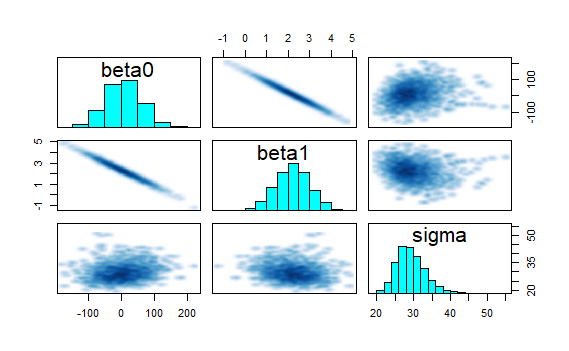

```r
pairs(fit_WtHt30, pars = c("beta0", "beta1", "sigma"))
```

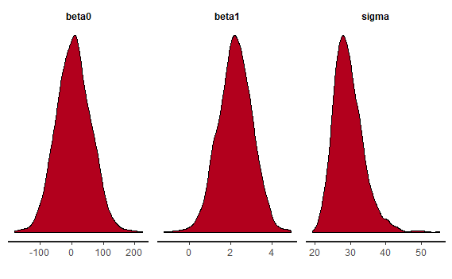

```r
plot(fit_WtHt30, plotfun = "dens", pars = c("beta0", "beta1", "sigma"))
```

```
ci_level: 0.8 (80% intervals)
outer_level: 0.95 (95% intervals)
```

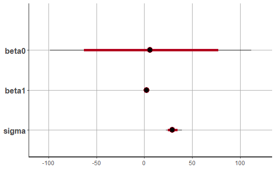

```r
plot(fit_WtHt30, pars = c("beta0", "beta1", "sigma"))
```

The huge range on the intercept is due to the fact that small changes to the slope way out to the right of the graph will result in lines that meet the y-axis in wildly different places. This is a good reason to standardize (or at least mean-center the data).

## The mean-centered model

```r
set.seed(11111)
fit_WtHt30_mc <- sampling(WtHt, data = stan_data_30_mc, refresh = 0)
```

Much better diagnostic plots:

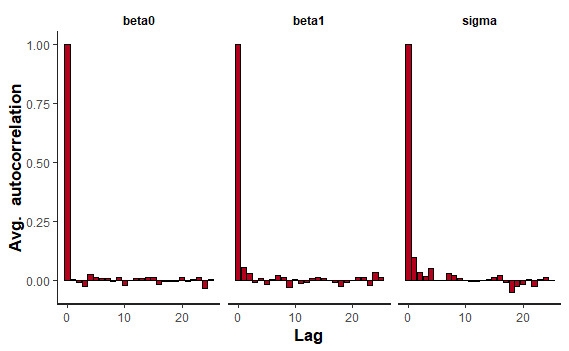

```r
plot(fit_WtHt30_mc, plotfun = "ac", pars = c("beta0", "beta1", "sigma"))
```

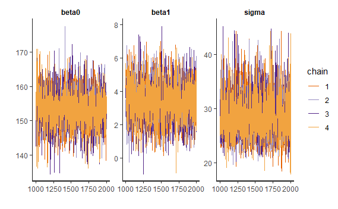

```r
plot(fit_WtHt30_mc, plotfun = "trace",
     pars = c("beta0", "beta1", "sigma"))
```

Reasonable values for the parameters and their standard deviations:

```r
print(fit_WtHt30_mc, pars = c("beta0", "beta1", "sigma"))
```

```
Inference for Stan model: stan-d2c73141751.
4 chains, each with iter=2000; warmup=1000; thin=1;
post-warmup draws per chain=1000, total post-warmup draws=4000.

        mean se_mean   sd   2.5%    25%    50%    75%  97.5% n_eff
beta0 153.50    0.08 5.25 143.27 150.16 153.48 156.85 163.86  3954
beta1   3.41    0.02 1.17   1.05   2.64   3.42   4.21   5.70  3520
sigma  28.66    0.08 4.09  22.15  25.74  28.15  31.13  37.87  2654
      Rhat
beta0    1
beta1    1
sigma    1

Samples were drawn using NUTS(diag_e) at Fri May 31 07:29:14 2019.
For each parameter, n_eff is a crude measure of effective sample size,
and Rhat is the potential scale reduction factor on split chains (at
convergence, Rhat=1).
```

The beta parameters are now uncorrelated:

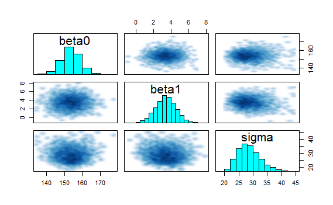

```r
pairs(fit_WtHt30_mc, pars = c("beta0", "beta1", "sigma"))
```

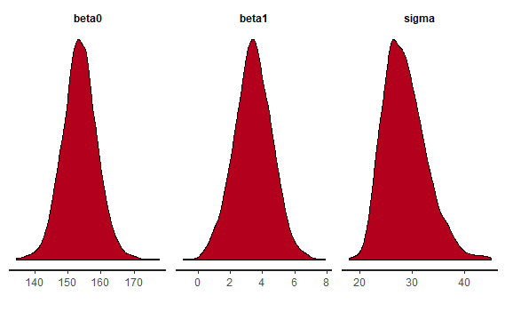

```r
plot(fit_WtHt30_mc, plotfun = "dens",
     pars = c("beta0", "beta1", "sigma"))
```

Tight estimates of the parameters:

```
ci_level: 0.8 (80% intervals)
outer_level: 0.95 (95% intervals)
```

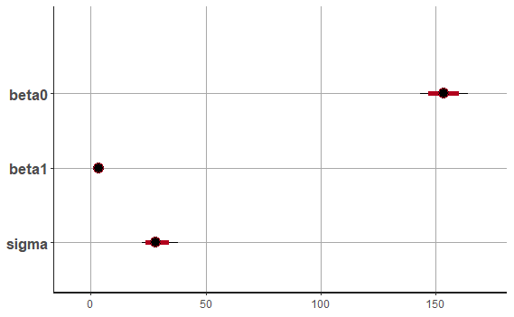

```r
plot(fit_WtHt30_mc, pars = c("beta0", "beta1", "sigma"))
```

## Examining the prior

```stan
data {
    int<lower = 0> N;
    vector[N] x;
    vector<lower = 0>[N] y;
}
transformed data {
    real<lower = 0> M0;
    real<lower = 0> S0;
    real<lower = 0> M1;
    real<lower = 0> S1;
    real<lower = 0> L;
    real<lower = 0> H;

    M0 = 70;
    S0 = 70;
    M1 = 0;
    S1 = 3;
    L = 0;
    H = 1000;
}
parameters {
    real beta0;
    real beta1;
    real<lower = 0> sigma;
}
transformed parameters {
    vector<lower = 0>[N] mu;

    mu = beta0 + beta1 * x;
}
model {
    beta0 ~ normal(M0, S0);
    beta1 ~ normal(M1, S1);
    sigma ~ uniform(L, H);
//    y ~ normal(mu, sigma);
}
```

```r
set.seed(11111)
fit_WtHt30_prior <- sampling(WtHt_prior, data = stan_data_30_mc, refresh = 0)
```

```
There were 3565 divergent transitions after warmup. Increasing adapt_delta above 0.8 may help. See
http://mc-stan.org/misc/warnings.html#divergent-transitions-after-warmupExamine the pairs() plot to diagnose sampling problems
```

```r
print(fit_WtHt30_prior, pars = c("beta0", "beta1", "sigma"))
```

```
Inference for Stan model: stan-d2c4e55b00.
4 chains, each with iter=2000; warmup=1000; thin=1;
post-warmup draws per chain=1000, total post-warmup draws=4000.

        mean se_mean     sd  2.5%    25%    50%    75%  97.5% n_eff
beta0  97.36    2.95  49.12 21.17  60.99  91.69 126.73 204.80   277
beta1   0.12    0.17   2.92 -5.72  -1.81   0.07   2.02   6.01   294
sigma 495.61   16.46 276.84 34.03 264.06 492.56 727.05 963.78   283
      Rhat
beta0 1.01
beta1 1.01
sigma 1.01

Samples were drawn using NUTS(diag_e) at Fri May 31 07:29:29 2019.
For each parameter, n_eff is a crude measure of effective sample size,
and Rhat is the potential scale reduction factor on split chains (at
convergence, Rhat=1).
```

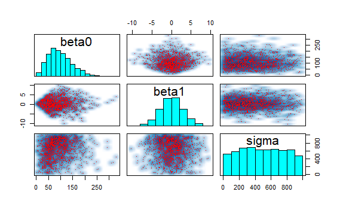

```r
pairs(fit_WtHt30_prior, pars = c("beta0", "beta1", "sigma"))
```

```
ci_level: 0.8 (80% intervals)
outer_level: 0.95 (95% intervals)
```

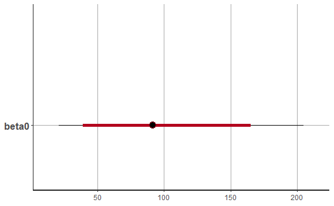

```r
plot(fit_WtHt30_prior, pars = c("beta0"))
```

```
ci_level: 0.8 (80% intervals)
outer_level: 0.95 (95% intervals)
```

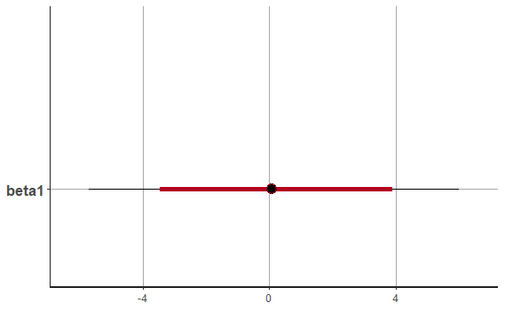

```r
plot(fit_WtHt30_prior, pars = c("beta1"))
```

```
ci_level: 0.8 (80% intervals)
outer_level: 0.95 (95% intervals)
```

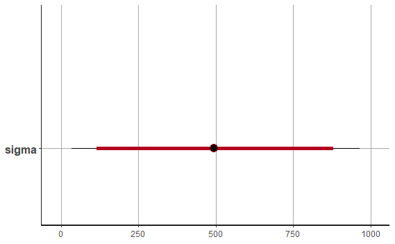

```r
plot(fit_WtHt30_prior, pars = c("sigma"))
```

## The model with 300 observations

```r
set.seed(11111)
fit_WtHt300_mc <- sampling(WtHt, data = stan_data_300_mc, refresh = 0)
```

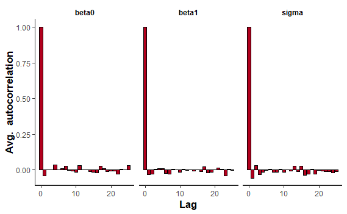

```r
plot(fit_WtHt300_mc, plotfun = "ac",
     pars = c("beta0", "beta1", "sigma"))
```

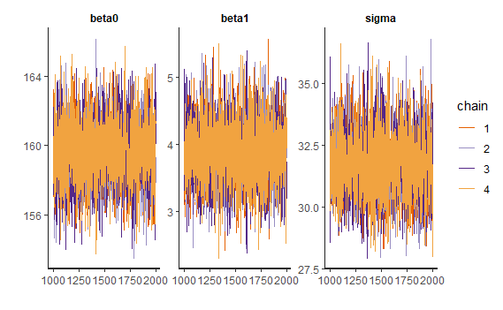

```r
plot(fit_WtHt300_mc, plotfun = "trace",
     pars = c("beta0", "beta1", "sigma"))
```

```r
print(fit_WtHt300_mc, pars = c("beta0", "beta1", "sigma"))
```

```
Inference for Stan model: stan-d2c73141751.
4 chains, each with iter=2000; warmup=1000; thin=1;
post-warmup draws per chain=1000, total post-warmup draws=4000.

        mean se_mean   sd   2.5%    25%    50%    75%  97.5% n_eff
beta0 159.54    0.03 1.82 155.91 158.33 159.58 160.73 163.17  4098
beta1   3.89    0.01 0.47   2.99   3.58   3.89   4.22   4.83  4269
sigma  31.72    0.02 1.30  29.33  30.81  31.66  32.59  34.32  4504
      Rhat
beta0    1
beta1    1
sigma    1

Samples were drawn using NUTS(diag_e) at Fri May 31 07:29:43 2019.
For each parameter, n_eff is a crude measure of effective sample size,
and Rhat is the potential scale reduction factor on split chains (at
convergence, Rhat=1).
```

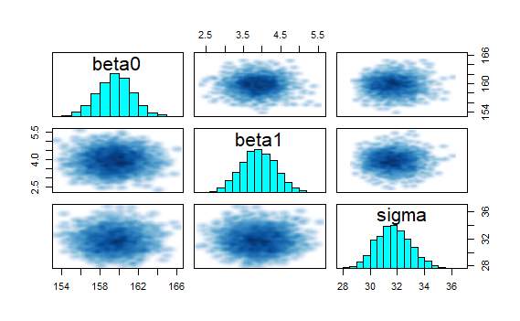

```r
pairs(fit_WtHt300_mc, pars = c("beta0", "beta1", "sigma"))
```

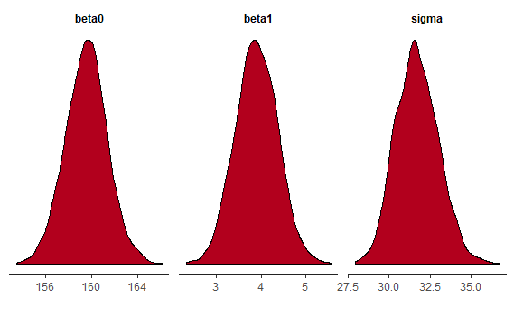

```r
plot(fit_WtHt300_mc, plotfun = "dens",
     pars = c("beta0", "beta1", "sigma"))
```

```
ci_level: 0.8 (80% intervals)
outer_level: 0.95 (95% intervals)
```

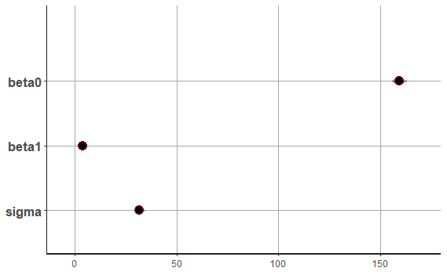

```r
plot(fit_WtHt300_mc, pars = c("beta0", "beta1", "sigma"))
```

## Posterior predictive check

We’ll just do this for the example with 30 observations.

```r
y <- y30
```

Extract predicted values:

```r
samples_WtHt30 <- extract(fit_WtHt30)
y_rep <- samples_WtHt30$y_rep
```

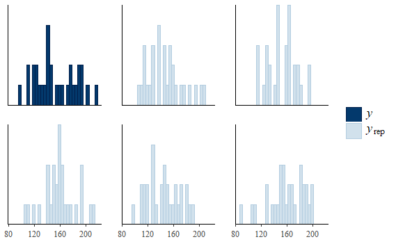

```r
ppc_hist(y, y_rep[1:5, ])
```

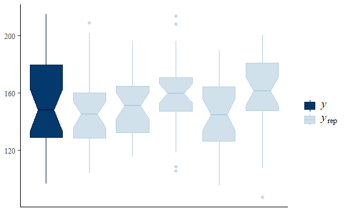

```r
ppc_boxplot(y, y_rep[1:5, ])
```

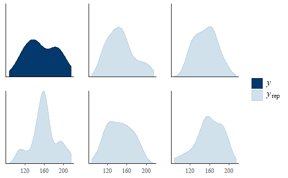

```r
ppc_dens(y, y_rep[1:5, ])
```

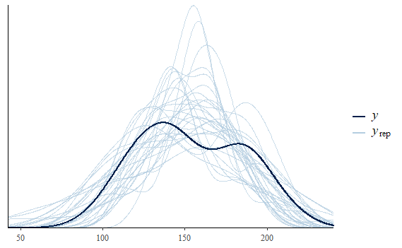

```r
ppc_dens_overlay(y, y_rep[1:30, ])
```

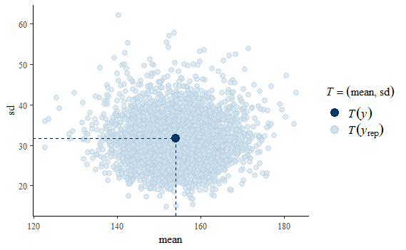

```r
ppc_stat_2d(y, y_rep)
```

## ShinyStan

Run the following code from the Console:

```
launch_shinystan(fit_WtHt30)
```